# Exploratory Data Analysis Project

#### Summary

- Most features are normally distributed.
- Some features contain outliers that should be fitted out of the viewing window where approriate

#### Bivariate/Multivariate analysis, correlations, and what influences quality

#### Acidity

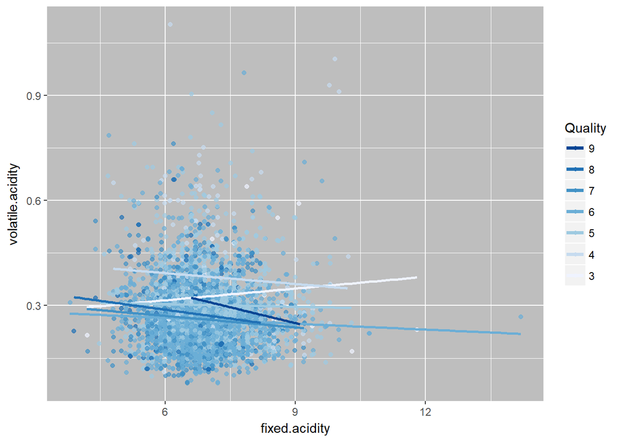

- Large cluster of wine with volatile acidity (0.15-0.60 g/L) and fixed acidity (4.5-9.0 g/L)
- Quality seems to be higher for lower concentration of acidity

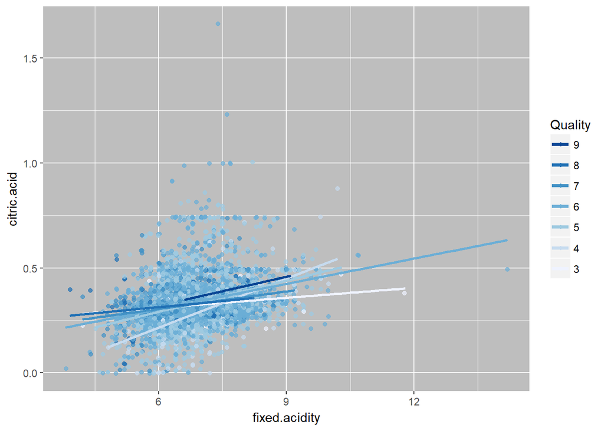

- Citric acid levels seem to be clustered below concentration (< 0.5 g/L)
- Regression for each quality rating seems model about the same
- Not a very good combination of features to determine quality

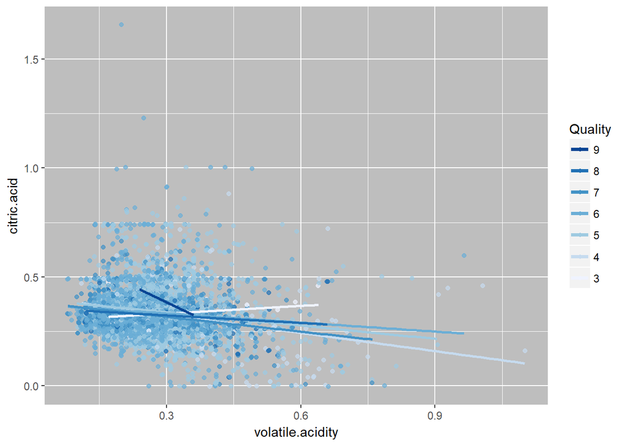

- Regression for each quality rating seems model about the same
- Not a very good combination of features to determine quality

#### Could high volatile acidity effect quality?

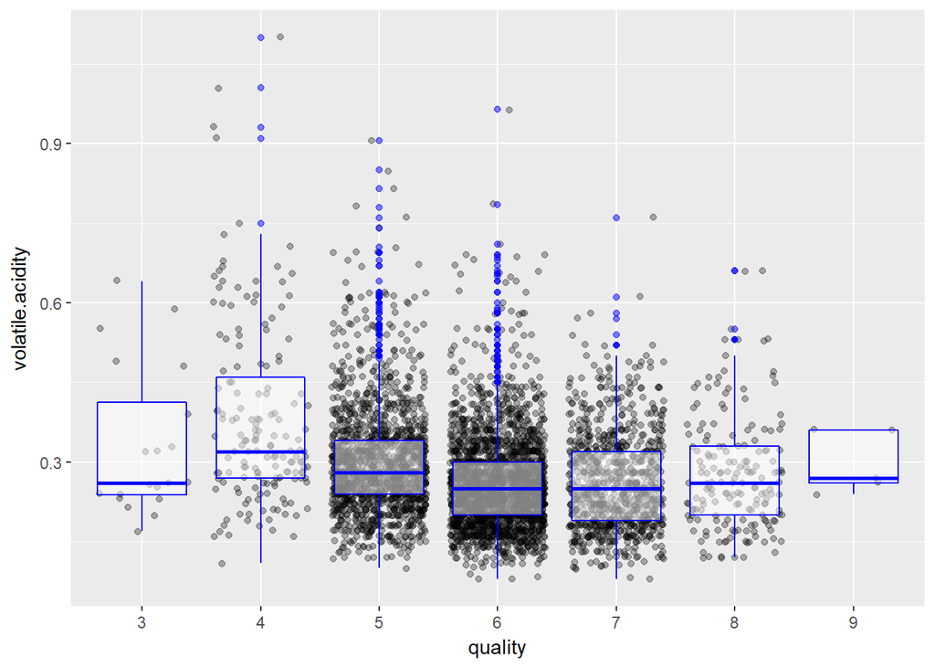

```
## [1] "Full dataset"
```

```
##
##  Pearson's product-moment correlation
##
## data:  as.numeric(quality) and volatile.acidity
## t = -13.891, df = 4896, p-value < 2.2e-16
## alternative hypothesis: true correlation is not equal to 0
## 95 percent confidence interval:
##  -0.2215214 -0.1676307
## sample estimates:
##       cor
## -0.194723
```

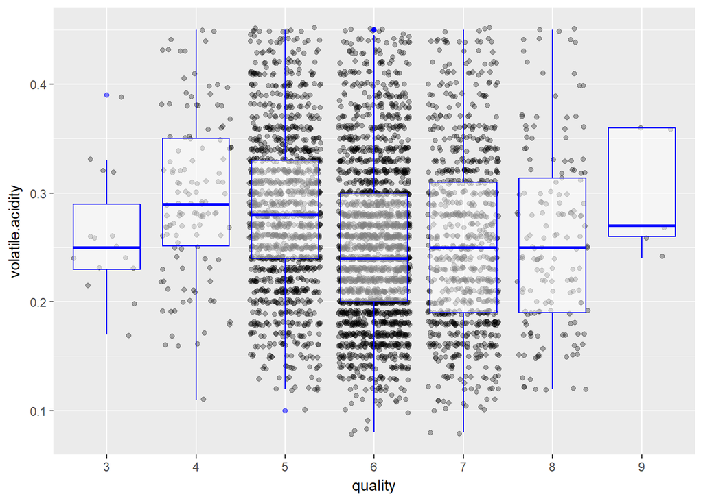

```
## [1] "Subset with volatile.acidity <= 0.45"
```

```
##
##  Pearson's product-moment correlation
##
## data:  as.numeric(quality) and volatile.acidity
## t = -9.9172, df = 4640, p-value < 2.2e-16
## alternative hypothesis: true correlation is not equal to 0
## 95 percent confidence interval:
##  -0.1721263 -0.1157827
## sample estimates:
##        cor
## -0.1440712
```

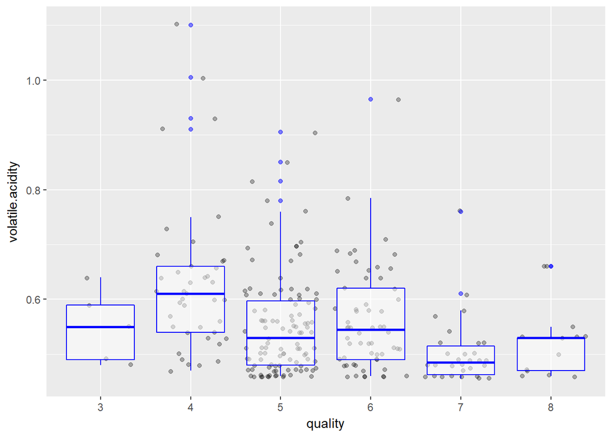

```
## [1] "Subset with volatile.acidity > 0.45"
```

```
##
##  Pearson's product-moment correlation
##
## data:  as.numeric(quality) and volatile.acidity
## t = -4.2265, df = 254, p-value = 3.313e-05
## alternative hypothesis: true correlation is not equal to 0
## 95 percent confidence interval:
##  -0.3673881 -0.1380690
## sample estimates:
##        cor
## -0.2563319
```

- Quality and volatile acidity are negatively correlated likely because at higher concentrations the acidity may be unpleasant to the drinker.
- Subsetting the data to an arbitrary level of volatile acidity (> 0.45 g/L) that includes more outliers, indicates that a stronger negative correlation exists at these extremes relative to the remainder of the dataset.

#### Does pH play a factor in quality?

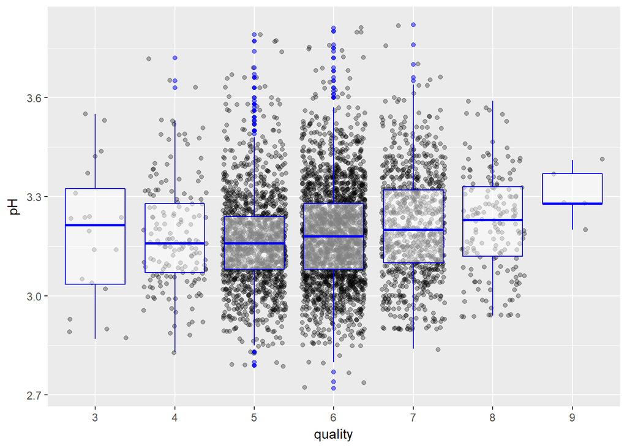

```
## [1] "pH Values across Quality Ratings"
```

```
## whites$quality: 3
##    Min. 1st Qu.  Median    Mean 3rd Qu.    Max.
##   2.870   3.035   3.215   3.188   3.325   3.550
## --------------------------------------------------------
## whites$quality: 4
##    Min. 1st Qu.  Median    Mean 3rd Qu.    Max.
##   2.830   3.070   3.160   3.183   3.280   3.720
## --------------------------------------------------------
## whites$quality: 5
##    Min. 1st Qu.  Median    Mean 3rd Qu.    Max.
##   2.790   3.080   3.160   3.169   3.240   3.790
## --------------------------------------------------------
## whites$quality: 6
##    Min. 1st Qu.  Median    Mean 3rd Qu.    Max.
##   2.720   3.080   3.180   3.189   3.280   3.810
## --------------------------------------------------------
## whites$quality: 7
##    Min. 1st Qu.  Median    Mean 3rd Qu.    Max.
##   2.840   3.100   3.200   3.214   3.320   3.820
## --------------------------------------------------------
## whites$quality: 8
##    Min. 1st Qu.  Median    Mean 3rd Qu.    Max.
##   2.940   3.120   3.230   3.219   3.330   3.590
## --------------------------------------------------------
## whites$quality: 9
##    Min. 1st Qu.  Median    Mean 3rd Qu.    Max.
##   3.200   3.280   3.280   3.308   3.370   3.410
```

```
##
##  Pearson's product-moment correlation
##
## data:  as.numeric(quality) and pH
## t = 6.9917, df = 4896, p-value = 3.081e-12
## alternative hypothesis: true correlation is not equal to 0
## 95 percent confidence interval:
##  0.07162022 0.12707983
## sample estimates:
##        cor
## 0.09942725
```

- 25-75% quantile range of pH does not vary much (within 0.3 units) between quality ratings
- pH has a very weak positive correlation with quality, probably not a useful feature for a linear model

#### Sugar, ions, and density

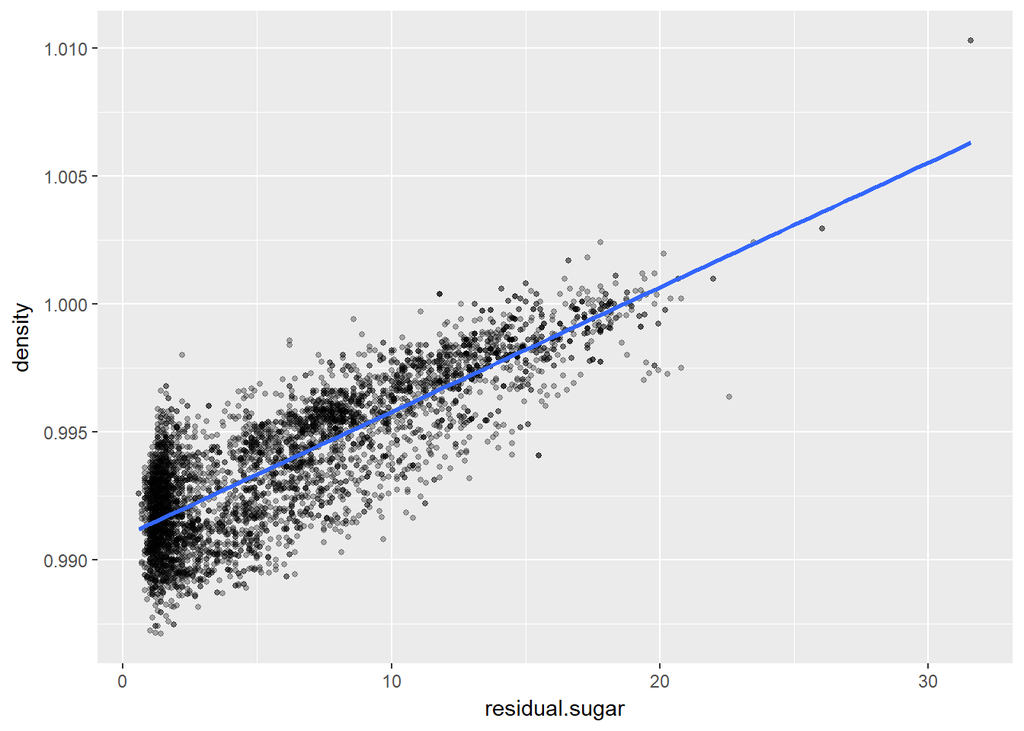

```
## $title
## [1] "Resized residual sugar"
##
## $subtitle
## NULL
##
## attr(,"class")
## [1] "labels"
```

```
## [1] "Summary of Residual Sugar"
```

```
##    Min. 1st Qu.  Median    Mean 3rd Qu.    Max.
##   0.600   1.700   5.200   6.391   9.900  65.800
```

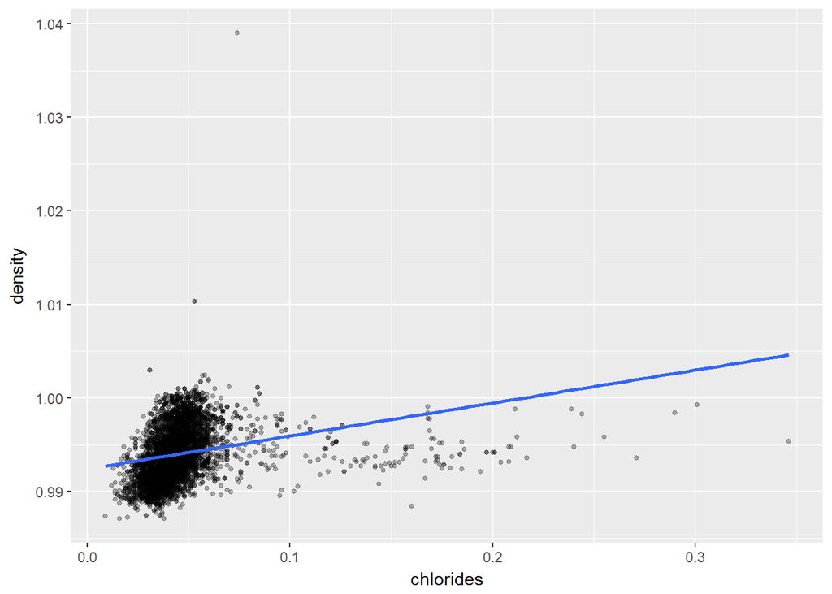

```
## [1] "Summary of Chlorides"
```

```
##    Min. 1st Qu.  Median    Mean 3rd Qu.    Max.
## 0.00900 0.03600 0.04300 0.04577 0.05000 0.34600
```

- Chloride count doesn’t seem to effect density by much likely do its relatively low concentration (median: 0.043 g/L vs 5.2 g/L for residual sugar)

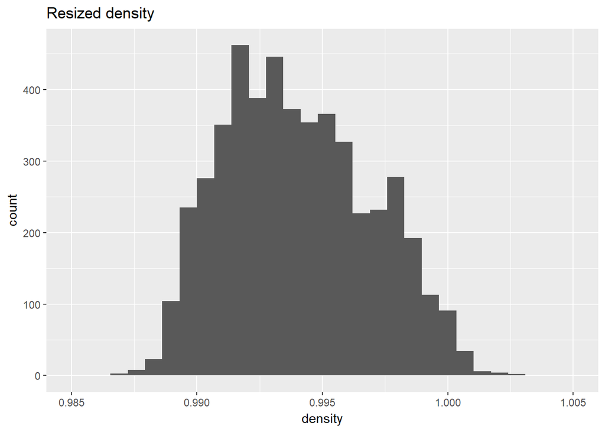

```
## [1] "Summary of Density"
```

```
##    Min. 1st Qu.  Median    Mean 3rd Qu.    Max.
##  0.9871  0.9917  0.9937  0.9940  0.9961  1.0390
```

```
##
##  Pearson's product-moment correlation
##
## data:  as.numeric(quality) and density
## t = -22.581, df = 4896, p-value < 2.2e-16
## alternative hypothesis: true correlation is not equal to 0
## 95 percent confidence interval:
##  -0.3322718 -0.2815385
## sample estimates:
##        cor
## -0.3071233
```

- Looking back at density from the univariate analysis,density values seem to be all about the same (25-75% quantile: 0.9917-0.9961), which initially made me conclude that it might not be a useful feature because perceiving the difference in density would be unlikely by a human.
- Although when checking density vs quality in a t-test, it showed a significant negative correlation

#### Taking a look at quality vs density

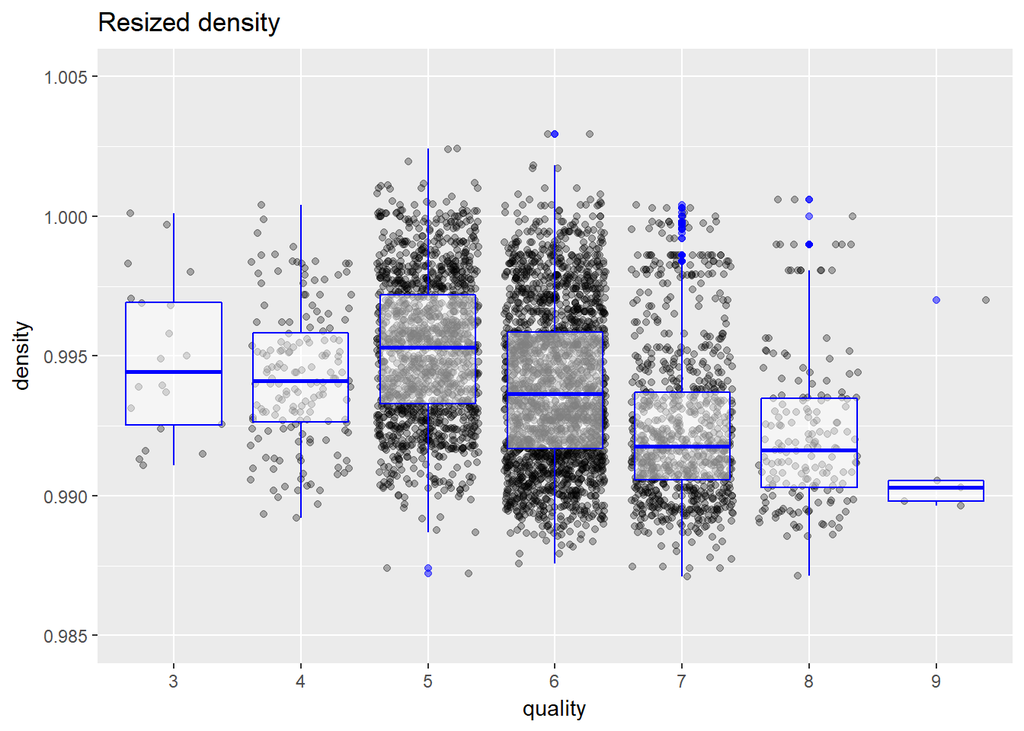

- Box plot shows a roughly negative correlation between quality and density
- Considering that density is determined by make up of the wine (solutes (ions, sugars, acids, etc), solvents (water, alcohol)) and that solvents are the largest contributor to a mixtures density, may want to look at alcohol and its relation to quality.

#### Does alcohol content contribute to the quality of wine?

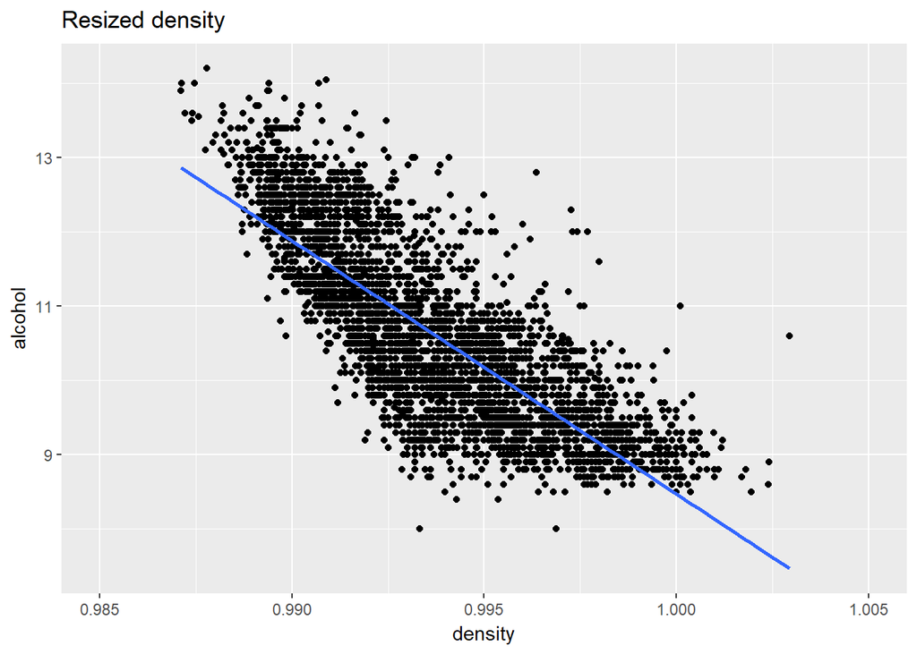

```
##
##  Pearson's product-moment correlation
##
## data:  density and alcohol
## t = -87.255, df = 4896, p-value < 2.2e-16
## alternative hypothesis: true correlation is not equal to 0
## 95 percent confidence interval:
##  -0.7908646 -0.7689315
## sample estimates:
##        cor
## -0.7801376
```

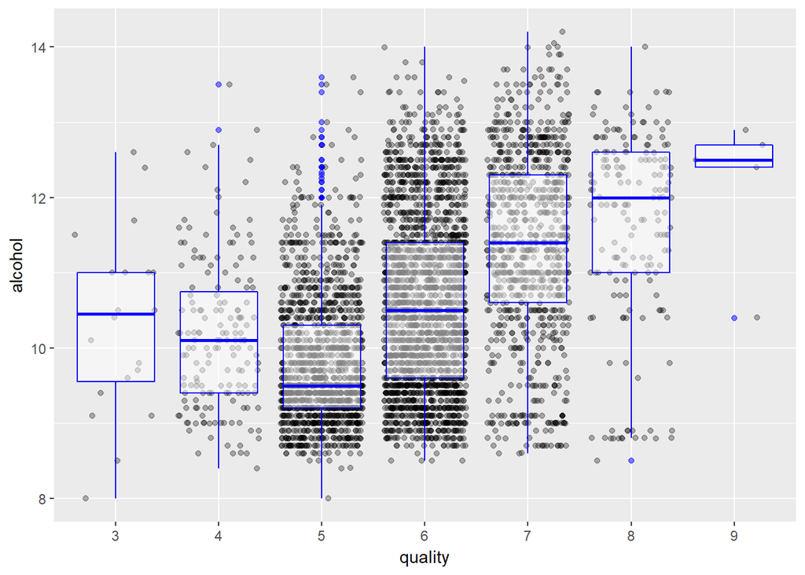

```
##
##  Pearson's product-moment correlation
##
## data:  as.numeric(quality) and alcohol
## t = 33.858, df = 4896, p-value < 2.2e-16
## alternative hypothesis: true correlation is not equal to 0
## 95 percent confidence interval:
##  0.4126015 0.4579941
## sample estimates:
##       cor
## 0.4355747
```

- Since as alcohol content increases wine density decreases (r = -0.78), the correlation of density with quality is probably more of a factor of alcohol concentration than density.
- This is apparent from the higher R-squared value for alcohol/quality than density/quality

#### Checking sulfurous contents

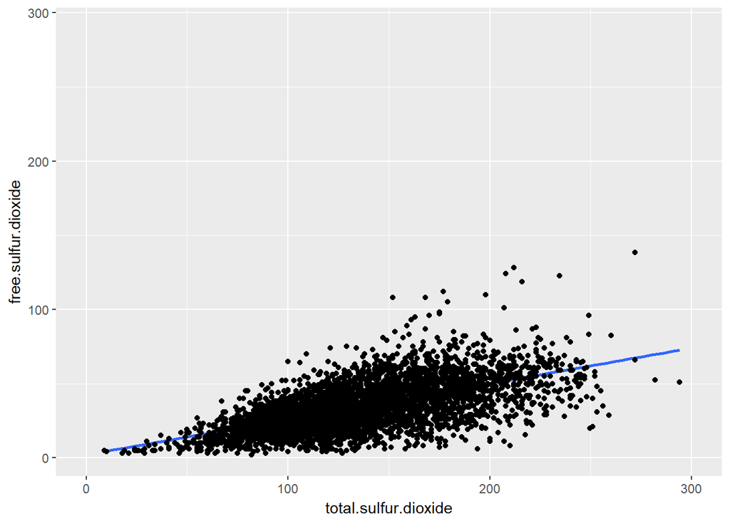

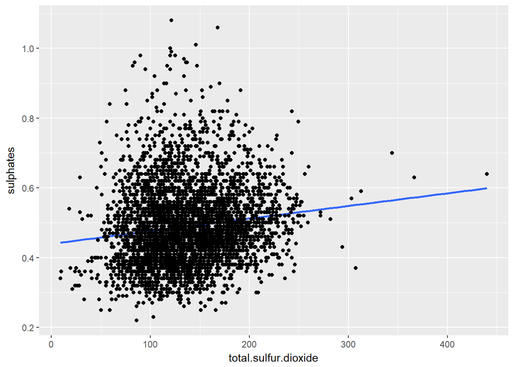

```
##
##  Pearson's product-moment correlation
##
## data:  total.sulfur.dioxide and free.sulfur.dioxide
## t = 54.645, df = 4896, p-value < 2.2e-16
## alternative hypothesis: true correlation is not equal to 0
## 95 percent confidence interval:
##  0.5977994 0.6326026
## sample estimates:
##      cor
## 0.615501
```

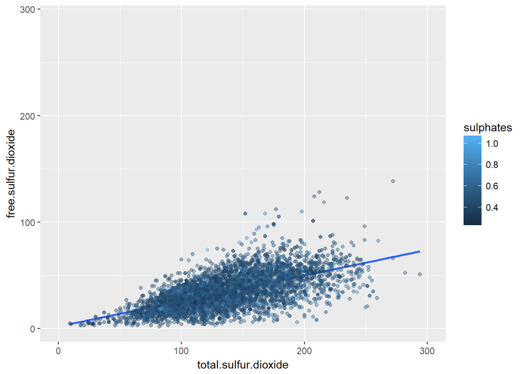

```
##
##  Pearson's product-moment correlation
##
## data:  total.sulfur.dioxide and sulphates
## t = 9.5019, df = 4896, p-value < 2.2e-16
## alternative hypothesis: true correlation is not equal to 0
## 95 percent confidence interval:
##  0.1069590 0.1619585
## sample estimates:
##       cor
## 0.1345624
```

```
##
##  Pearson's product-moment correlation
##
## data:  sulphates and free.sulfur.dioxide
## t = 4.1508, df = 4896, p-value = 3.369e-05
## alternative hypothesis: true correlation is not equal to 0
## 95 percent confidence interval:
##  0.03126264 0.08707928
## sample estimates:
##        cor
## 0.05921725
```

- Note that sulfur dioxide concentrations are in mg/L vs sulphates which is in g/L
- Total sulfur dioxide has a moderate positive correlation with free sulfur dioxide concentrations, while both variables have weak positive correlations with sulphate concentration
- Note that a significant amount of wines have free sulfur dioxide concentrations greater than 50 ppm (0.05 g/L or 50 mg/L) which can be unpleasant; may want to subset that data since sulfur dioxide will then be detectable by smell by given definition

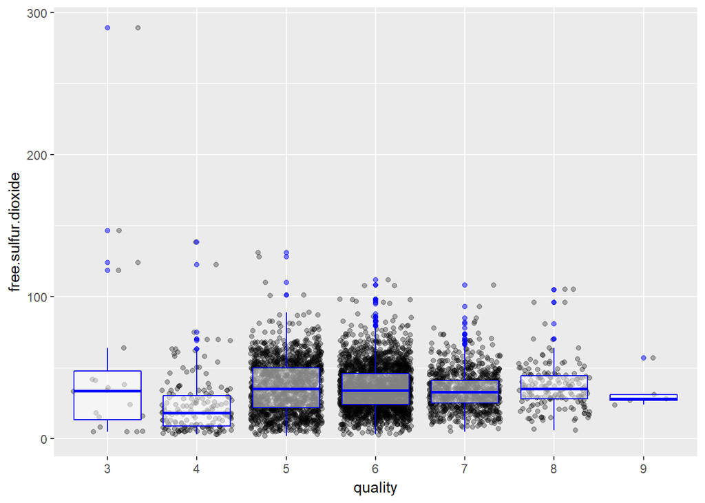

```
## [1] "Full Dataset"
```

```
##
##  Pearson's product-moment correlation
##
## data:  as.numeric(quality) and free.sulfur.dioxide
## t = 0.57085, df = 4896, p-value = 0.5681
## alternative hypothesis: true correlation is not equal to 0
## 95 percent confidence interval:
##  -0.01985292  0.03615626
## sample estimates:
##         cor
## 0.008158067
```

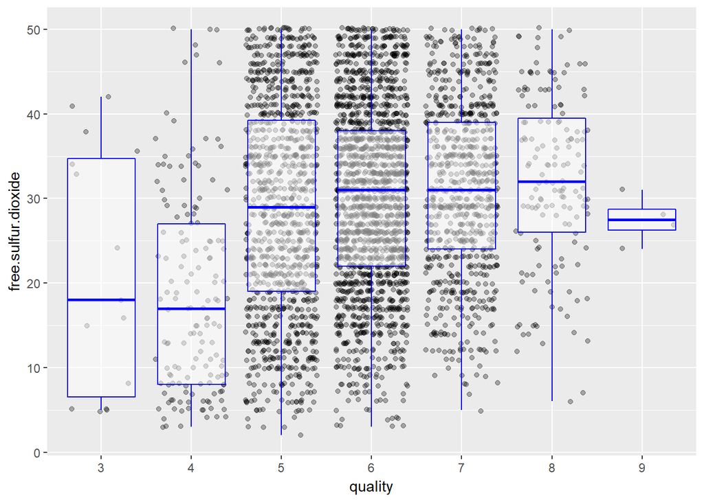

```
## [1] "Subset with free.sulfur.dioxide <= 50"
```

```
##
##  Pearson's product-moment correlation
##
## data:  as.numeric(quality) and free.sulfur.dioxide
## t = 10.337, df = 4028, p-value < 2.2e-16
## alternative hypothesis: true correlation is not equal to 0
## 95 percent confidence interval:
##  0.1305243 0.1906818
## sample estimates:
##       cor
## 0.1607524
```

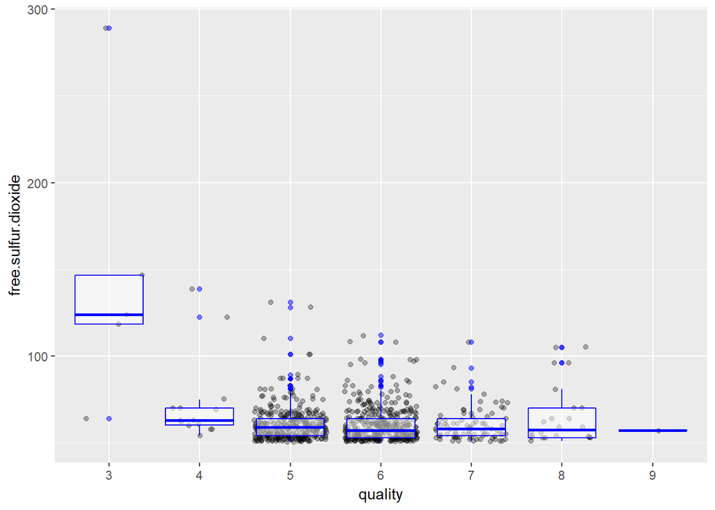

```
## [1] "Subset with free.sulfur.dioxide > 50"
```

```
##
##  Pearson's product-moment correlation
##
## data:  as.numeric(quality) and free.sulfur.dioxide
## t = -3.812, df = 866, p-value = 0.0001476
## alternative hypothesis: true correlation is not equal to 0
## 95 percent confidence interval:
##  -0.19335188 -0.06245395
## sample estimates:
##        cor
## -0.1284624
```

- There exists no significant correlation of quality with free sulfur dioxide concentration, but when the dataset is subset to detectable free sulfur dioxide by smell (concentration >= 50 ppm) and nondetectable free sulfur dioxide by smell (concentration < 50 ppm) there exists a significant negative and positive correlation respectively.

### Creating a Linear Model to determine quality

```
## [1] "Full dataset"
```

```
##
## Calls:
## x1: lm(formula = as.numeric(quality) ~ alcohol, data = whites)
## x2: lm(formula = as.numeric(quality) ~ alcohol + volatile.acidity,
##     data = whites)
## x3: lm(formula = as.numeric(quality) ~ alcohol + volatile.acidity +
##     free.sulfur.dioxide, data = whites)
##
## =================================================================
##                             x1            x2            x3
## -----------------------------------------------------------------
##   (Intercept)              0.582***      1.017***      0.604***
##                           (0.098)       (0.098)       (0.109)
##   alcohol                  0.313***      0.324***      0.343***
##                           (0.009)       (0.009)       (0.009)
##   volatile.acidity                      -1.979***     -1.904***
##                                         (0.110)       (0.109)
##   free.sulfur.dioxide                                  0.006***
##                                                       (0.001)
## -----------------------------------------------------------------
##   R-squared                0.190         0.240         0.251
##   adj. R-squared           0.190         0.240         0.250
##   sigma                    0.797         0.772         0.767
##   F                     1146.395       773.875       546.017
##   p                        0.000         0.000         0.000
##   Log-likelihood       -5839.391     -5681.776     -5647.564
##   Deviance              3112.257      2918.264      2877.780
##   AIC                  11684.782     11371.552     11305.127
##   BIC                  11704.272     11397.538     11337.610
##   N                     4898          4898          4898
## =================================================================
```

```
## [1] "Subset of non-smelly wines"
```

```
##
## Calls:
## m1: lm(formula = as.numeric(quality) ~ alcohol, data = subset(whites,
##     free.sulfur.dioxide <= 50))
## m2: lm(formula = as.numeric(quality) ~ alcohol + volatile.acidity,
##     data = subset(whites, free.sulfur.dioxide <= 50))
## m3: lm(formula = as.numeric(quality) ~ alcohol + volatile.acidity +
##     free.sulfur.dioxide, data = subset(whites, free.sulfur.dioxide <=
##     50))
##
## =================================================================
##                             m1            m2            m3
## -----------------------------------------------------------------
##   (Intercept)              0.620***      1.004***      0.273*
##                           (0.111)       (0.110)       (0.118)
##   alcohol                  0.309***      0.324***      0.343***
##                           (0.010)       (0.010)       (0.010)
##   volatile.acidity                      -1.948***     -1.747***
##                                         (0.120)       (0.118)
##   free.sulfur.dioxide                                  0.016***
##                                                       (0.001)
## -----------------------------------------------------------------
##   R-squared                0.182         0.232         0.271
##   adj. R-squared           0.181         0.232         0.271
##   sigma                    0.812         0.787         0.766
##   F                      894.023       608.181       499.911
##   p                        0.000         0.000         0.000
##   Log-likelihood       -4877.850     -4749.914     -4643.721
##   Deviance              2655.568      2492.203      2364.261
##   AIC                   9761.700      9507.829      9297.442
##   BIC                   9780.605      9533.035      9328.949
##   N                     4030          4030          4030
## =================================================================
```

```
## [1] "Subset of smelly wines"
```

```
##
## Calls:
## n1: lm(formula = as.numeric(quality) ~ alcohol, data = subset(whites,
##     free.sulfur.dioxide > 50))
## n2: lm(formula = as.numeric(quality) ~ alcohol + volatile.acidity,
##     data = subset(whites, free.sulfur.dioxide > 50))
## n3: lm(formula = as.numeric(quality) ~ alcohol + volatile.acidity +
##     free.sulfur.dioxide, data = subset(whites, free.sulfur.dioxide >
##     50))
##
## ==============================================================
##                            n1           n2           n3
## --------------------------------------------------------------
##   (Intercept)             0.024        0.897***     1.393***
##                          (0.253)      (0.271)      (0.284)
##   alcohol                 0.373***     0.343***     0.348***
##                          (0.026)      (0.025)      (0.025)
##   volatile.acidity                    -2.133***    -2.158***
##                                       (0.283)      (0.279)
##   free.sulfur.dioxide                              -0.009***
##                                                    (0.002)
## --------------------------------------------------------------
##   R-squared               0.198        0.247        0.270
##   adj. R-squared          0.197        0.246        0.267
##   sigma                   0.723        0.701        0.691
##   F                     214.004      142.213      106.369
##   p                       0.000        0.000        0.000
##   Log-likelihood       -949.065     -921.527     -908.490
##   Deviance              452.642      424.813      412.242
##   AIC                  1904.131     1851.054     1826.981
##   BIC                  1918.429     1870.119     1850.812
##   N                     868          868          868
## ==============================================================
```

- Subsetting the free sulfur dioxide feature shows a slight improvement in overall R^2 with the combined linear model (alcohol, volatile.acidity, free.sulfur.dioxide) vs not-subsetting the free sulfur dioxide feature